# Multiple Linear Regression

Author : Rose Ellison

I will be building a multiple linear regression model based off the ‘50_Startups’ data and using the forward elimination model. In this dataset there are five columns $Profit$, $R.D.Spend$, $Administration$, $Marketing$, and $State$. Profit is our dependent variable while the other four are our independent variables. We want to determine if there are any correlations between the profit and expenditures, such as r&d, admin, and marketing. Additionally, is there any correlation between profit and which state the company is operating?

$$Multiple Linear Regression Formula :$$

$$y = b_0 + b_1 x_1 + b_2 x_2 + b_3 x_3 + b_4 x_4$$

## Preparing the data

For this step, I need to read in the csv file, deal with categorical data, and then split the data into training and test sets.

```r
# Importing the dataset
startups <- read.csv('../data/50_Startups.csv')


# Dealing with categorical data - 'State'
# Encoding
startups$State <- factor(startups$State,
                         levels <- c('New York', 'California', 'Florida'),
                         labels <- c(1, 2, 3))


# Splitting the data into test and training sets
set.seed(1)
split <- sample.split(startups$Profit, SplitRatio = .8)
training.set <- subset(startups, split == TRUE)
test.set <- subset(startups, split == FALSE)
```

## Fitting Multiple Linear Regression to the Training Set

```r
# Regressor with all dependent variables
regressor <-  lm(Profit ~ ., training.set)
summary(regressor)
```

```
##
## Call:
## lm(formula = Profit ~ ., data = training.set)
##
## Residuals:
##      Min       1Q   Median       3Q      Max
## -30230.1  -3255.0    606.6   6683.7  13424.8
##
## Coefficients:
##                   Estimate Std. Error t value Pr(>|t|)
## (Intercept)      5.203e+04  7.535e+03   6.905  5.9e-08 ***
## R.D.Spend        8.612e-01  5.468e-02  15.749  < 2e-16 ***
## Administration  -7.261e-02  5.923e-02  -1.226    0.229
## Marketing.Spend  1.893e-02  1.926e-02   0.983    0.332
## State2           5.173e+02  3.688e+03   0.140    0.889
## State3          -1.967e+02  3.728e+03  -0.053    0.958
## ---
## Signif. codes:  0 '***' 0.001 '**' 0.01 '*' 0.05 '.' 0.1 ' ' 1
##
## Residual standard error: 9365 on 34 degrees of freedom
## Multiple R-squared:  0.955,  Adjusted R-squared:  0.9483
## F-statistic: 144.2 on 5 and 34 DF,  p-value: < 2.2e-16
```

According to the data, the only strong predictor in profit is the r&d spend. Due to this, we could rewrite our regressor with only one dependent variable and we should still get the same results.

```r
# Regressor with only the R.D.Spend dependent variable
regressor <-  lm(Profit ~ R.D.Spend, training.set)
summary(regressor)
```

```
##
## Call:
## lm(formula = Profit ~ R.D.Spend, data = training.set)
##
## Residuals:
##      Min       1Q   Median       3Q      Max
## -31194.8  -4500.5     58.8   5638.2  17478.7
##
## Coefficients:
##              Estimate Std. Error t value Pr(>|t|)
## (Intercept) 4.588e+04  2.823e+03   16.25   <2e-16 ***
## R.D.Spend   8.836e-01  3.283e-02   26.91   <2e-16 ***
## ---
## Signif. codes:  0 '***' 0.001 '**' 0.01 '*' 0.05 '.' 0.1 ' ' 1
##
## Residual standard error: 9318 on 38 degrees of freedom
## Multiple R-squared:  0.9502, Adjusted R-squared:  0.9488
## F-statistic: 724.4 on 1 and 38 DF,  p-value: < 2.2e-16
```

Although we changed the regressor to only using the R.D.Spend variable, the p-value remains the same. This is another indication that R.D.Spend is the only strong dependent variable predictor.

## Predicting the Test Set Results

```r
y.pred <- predict(regressor, newdata = test.set)
```

## Visualizing the training set

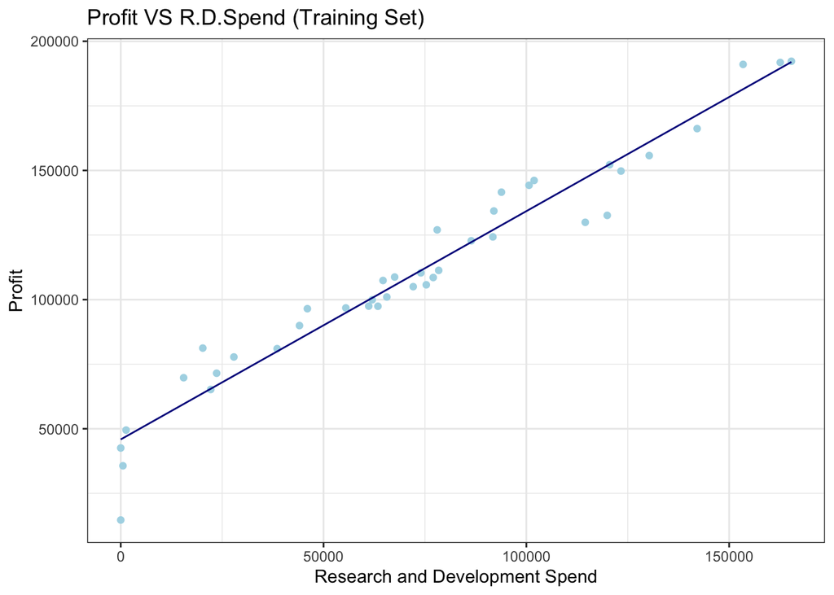

```r
# Visualizing the training set results
ggplot() +
  geom_point(aes(x = training.set$R.D.Spend, y = training.set$Profit), col = 'lightblue', lw = 4) +
  geom_line(aes(x = training.set$R.D.Spend, y = predict(regressor, newdata = training.set)), col = 'darkblue') +
  theme_bw() +
  ggtitle('Profit VS R.D.Spend (Training Set)') +
  xlab('Research and Development Spend') +
  ylab('Profit')
```

## Visualizing the test set results

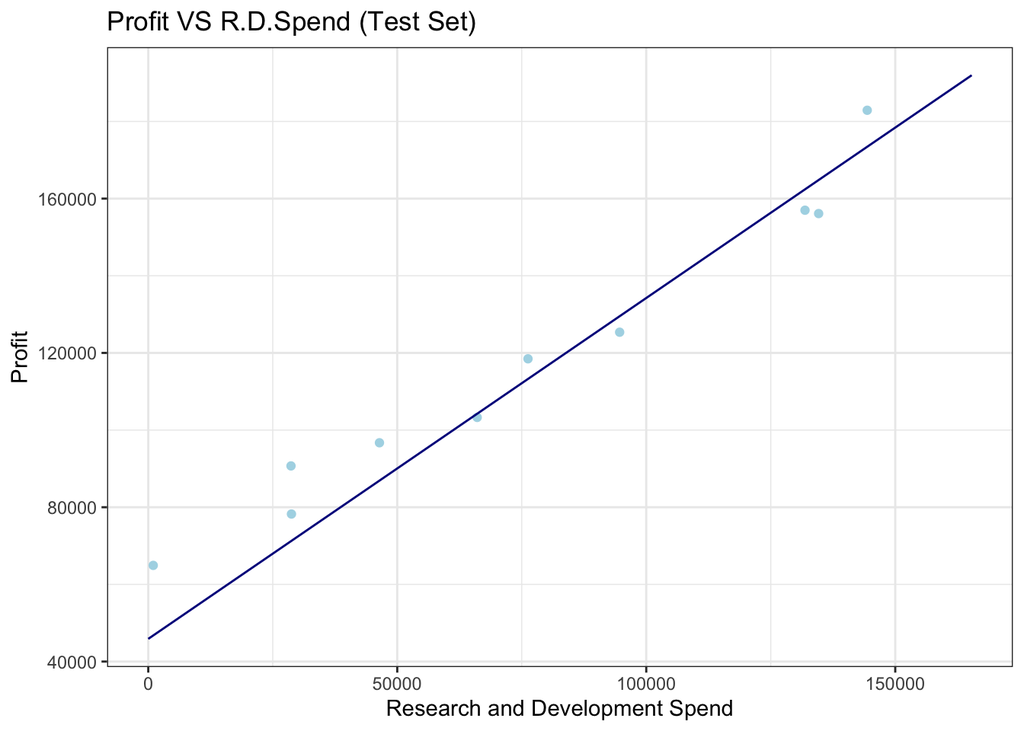

```r
ggplot() +
  geom_point(aes(x = test.set$R.D.Spend, y = test.set$Profit), col = 'lightblue', lw = 4) +
  geom_line(aes(x = training.set$R.D.Spend, y = predict(regressor, newdata = training.set)), col = 'darkblue') +
  theme_bw() +
  ggtitle('Profit VS R.D.Spend (Test Set)') +
  xlab('Research and Development Spend') +
  ylab('Profit')
```